# MScA, Bayesian Methods (32014) Week 6 Workshop 2 Review of Hierarchical Models, Shrinkage and MCMC

Yuri Balasanov, © iLykei 2016

# 1 References

[G] Andrew Gelman, John B. Carlin, Hal S. Stern, David B. Dunson, Aki Vehtari, Donald B. Rubin, Bayesian Data Analysis, Third Edition, 2013, Taylor & Francis Group.  
[K] John K. Kruschke, Doing Bayesian Data Analysis, A Tutorial with R, JAGS, and STAN, 2015, Elsevier.

# 2 Review of MCMC: binomial model

Code MCMC algorithm for simplest binomial model with conjugate beta prior.

Model description contains 2 parts:
$$y_i \sim Binom(p=\theta,size=1),$$
$$\theta \sim Beta(A_{prior},B_{prior}),$$
where $\theta$ is the unknown probability of success with prior beta distribution with fixed parameters $A,~B$.

To check the resuls of simulation use analytical formulas for posterior distribution: if prior beta distribution has parameters $A_{prior},~B_{prior}$ and the data contain number of successes $s$,
$$s= \sum_{i=1}^{k} y_i,$$
out of $k$ observations then posterior beta distribution has parameters
$$A_{post}=A_{prior}+s,~B_{post}=B_{prior}+k-s.$$

## 2.1 Data

Create vector of zeros and ones of length $k=20$ and probability of success $\theta=0.6$.

```r
set.seed(9374)
Y<-rbinom(20,size=1,p=.6)
```

## 2.2 Running MCMC

Recall that Metropolis-Hastings MCMC algorithm consists of the following steps:

### 2.2.1 Generate new proposal using some convenient distribution.

Typically new proposals are generated from Gaussian distribution centered at the current value of Markov chain with sufficiently small variance.  
Write a function for new proposals `proposalFun<-function(oldTheta)` which simulates `newTheta` from Gaussian distribution with mean value `oldTheta` and fixed standard deviation of small enough level to generate reasonable proposals for $\theta$ between 0 and 1.  
It is recommended to truncate the proposed values between extreme levels of, for example, 0.01 and 0.99 to prevent values exactly at 0 and 1.

(Skipped Code)

### 2.2.2 Decide whether the proposal `newTheta` is accepted or rejected.

To do that follow the logic:

- If posterior probability density at `newTheta` is greater than posterior probability density at `oldTheta` then accept `newTheta` into the chain sample.
- If posterior probability density at `newTheta` is smaller than posterior probability density at `oldTheta` then accept `newTheta` with probability
  $$p_{dec}=\frac{p(\theta_{new}|y)}{p(\theta_{old}|y)}=\frac{p(y|\theta_{new})p(\theta_{new}|A,B)}{p(y|\theta_{old})p(\theta_{old}|A,B)}$$
  and reject `newTheta` with probability $1-p_{dec}$.
- Acceptance decision is made by simulating uniform random variable on [0,1] $U$ and comparing it with $p_{dec}$. If $U<p_{dec}$ then `newTheta` is accepted.

Write function `binomialLikelihood<-function(Theta,Size,mySample)` that calculates binomial likelihood $p(\theta|y)$ of sample `mySample` with binomial parameters `Theta` and size `Size`.

Also write function `binomialPrior<-function(Theta,A,B)` that calculates prior distribution density $p(\theta|A,B)$ for given value `Theta` and fixed beta distribution parameters $A_{prior},~B_{prior}$.

(Skipped Code)

Finally, write decision function `metropolisRule<-function(thetaOld,thetaNew,mySample,funLikelihood,funPrior)`.  
This function takes `thetaOld`, `thetaNew` and calculates $p_{dec}$.  
Then depending on the value of $p_{dec}$ the function returns value `Rejection` equal to `TRUE` if `thetaNew` is rejected and `FALSE` if not.

(Skipped Code)

### 2.2.3 Initiate parameters

When all functions are prepared initiate necessary parameters:

```r
# Initiate
chainMax<-500               # length of Markov chain
Chain<-numeric(0)           # empty vector for the chain
Rejected<-numeric(0)        # empty vector for rejected values
chainLength<-length(Chain)  # current length of chain
tuneSigma<-.1               # standard deviation of proposal distribution
priorParam<-c(A=10,B=10)    # parameters of prior beta distribution
ExtraParameters<-c(20,priorParam["A"],priorParam["B"])
names(ExtraParameters)<-c("Size","A","B")
ExtraParameters             # all extra global parameters
```

```
## Size    A    B
##   20   10   10
```

```r
ThetaOld<-.5                # initial Theta
```

### 2.2.4 Run MCMC

Run loop until number of accepted values in `Chain` reaches `chainMax`.

In this loop:

- Generate new proposal `ThetaNew`
- Apply Metropolis decision rule. If new proposal is accepted add it to `Chain` and increase `chainLength`, then reset `ThetaOld` to `ThetaNew`. If new proposal is rejected then add it to vector `Rejected`

(Skipped Code)

## 2.3 Checking results

After simulating Markov chain check the results.

### 2.3.1 Analytical solution

Compare prior parameters and posterior parameters given by formulas

```r
priorParam
```

```
##  A  B
## 10 10
```

```r
posteriorParam<-priorParam+c(sum(Y),length(Y)-sum(Y))
```

Compare mean values of prior and posterior distributions with MLE.

```r
meanValues<-c(Prior=priorParam[1]/sum(priorParam),
              MLE=mean(Y),
              Posterior=posteriorParam[1]/sum(posteriorParam))
names(meanValues)<-c("Prior","MLE","Posterior")
meanValues
```

```
##     Prior       MLE Posterior
##      0.50      0.60      0.55
```

### 2.3.2 Histograms of accepted and rejected values

Look at histogram of the simulated chain and histogram of rejected values.

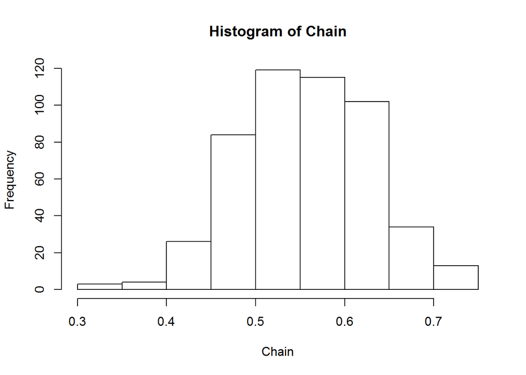

```r
hist(Chain)
```

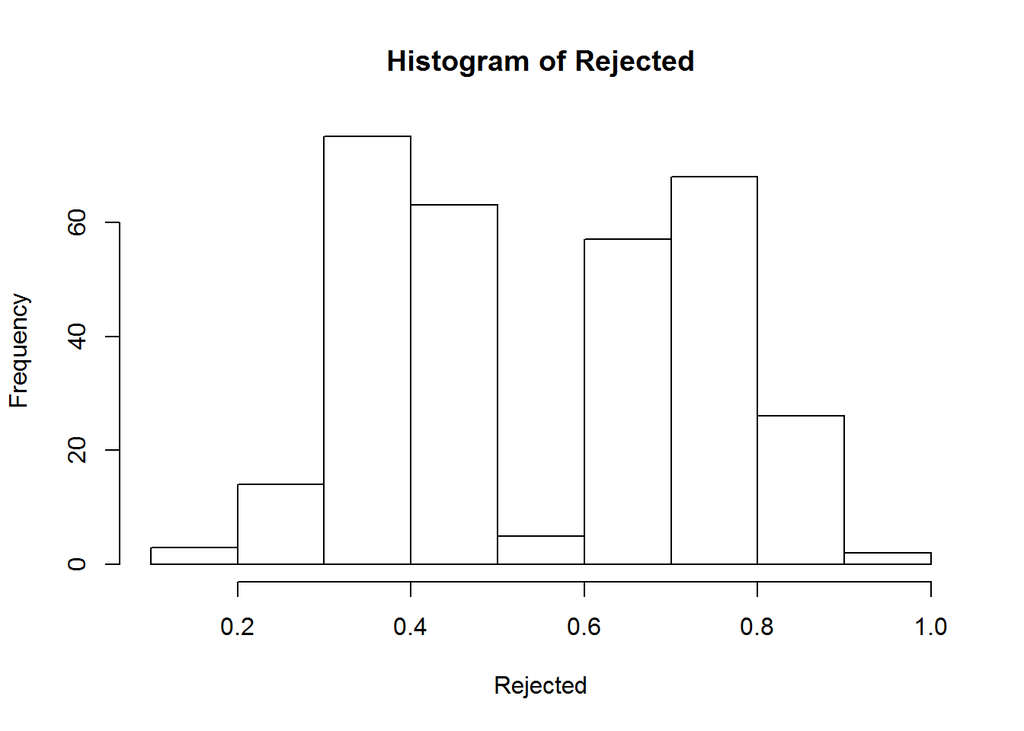

```r
hist(Rejected)
```

**Interpret the histograms**.

Compare distribution of the simulated Markov chain with the analytical posterior distribution.

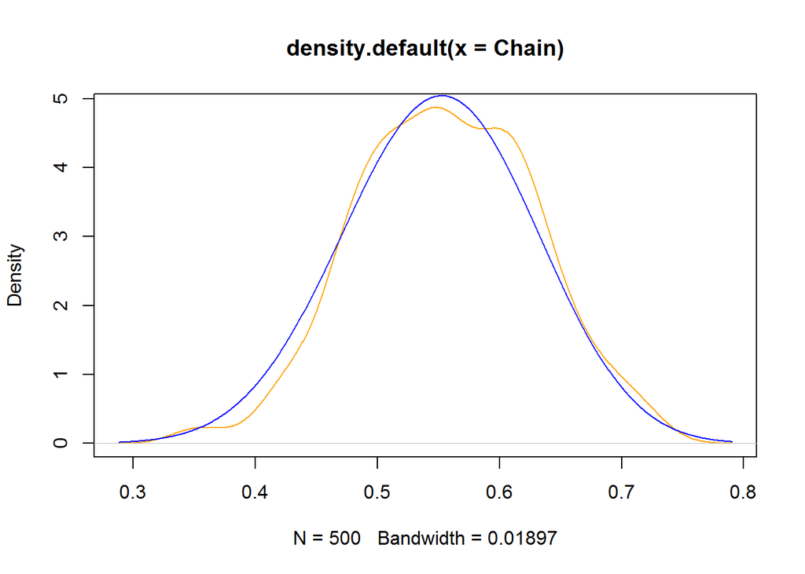

```r
den<-density(Chain)
plot(den,col="orange")
lines(den$x,dbeta(den$x,posteriorParam[1],posteriorParam[2]),type="l",col="blue")
```

Compare prior and posterior densities.

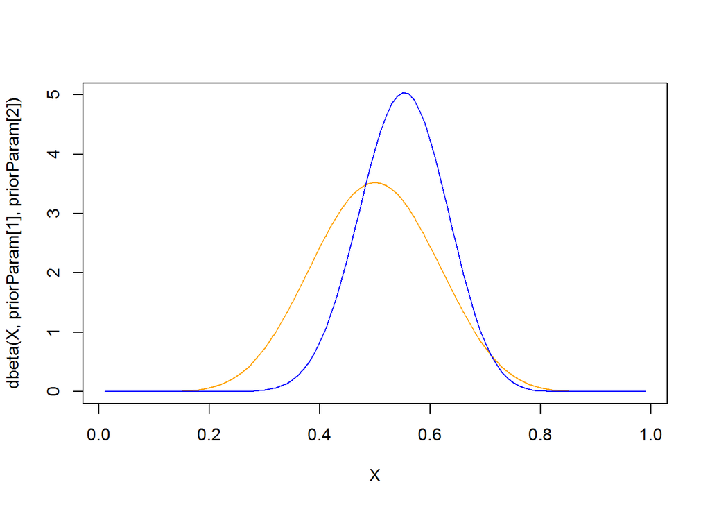

```r
X<-seq(from=.01,to=.99,by=.01)
plot(X,dbeta(X,priorParam[1],priorParam[2]),type="l",col="orange",ylim=c(0,5))
lines(X,dbeta(X,posteriorParam[1],posteriorParam[2]),type="l",col="blue")
```

# 3 Gaussian distribution, one sample: known variance, unknown mean

## 3.1 Data

Simulate single sample from Gaussian distribution with unknown mean $\theta$ and known standard deviation $\sigma$.

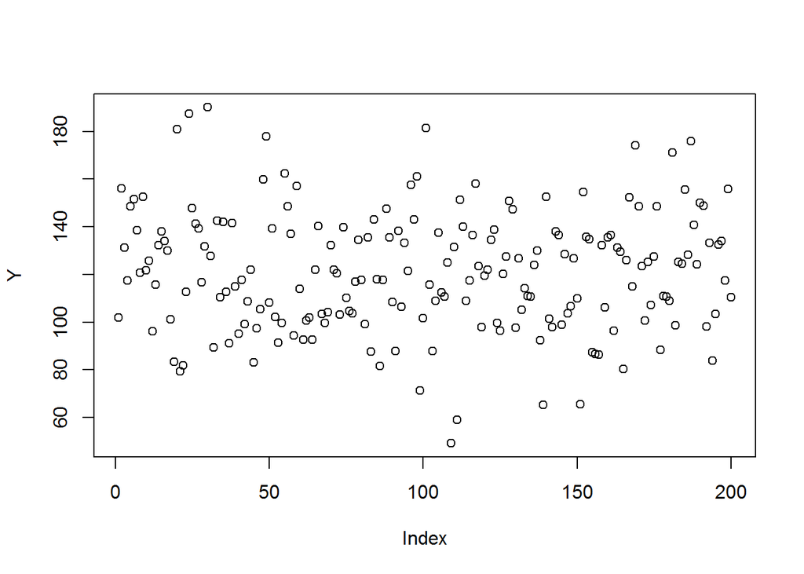

```r
mu<-120
si<-25
nSample<-200
set.seed(7036)
Y<-rnorm(nSample,mean=mu,sd=si)
Theoretical.data<-c(Mean=mu,Sd=si)
plot(Y)
```

## 3.2 FNP approach

Estimate mean of the distribution, check histogram, test hypothesis $H_0: \mu=120$ against two-sided alternative $H_a: \mu \ne 120$.

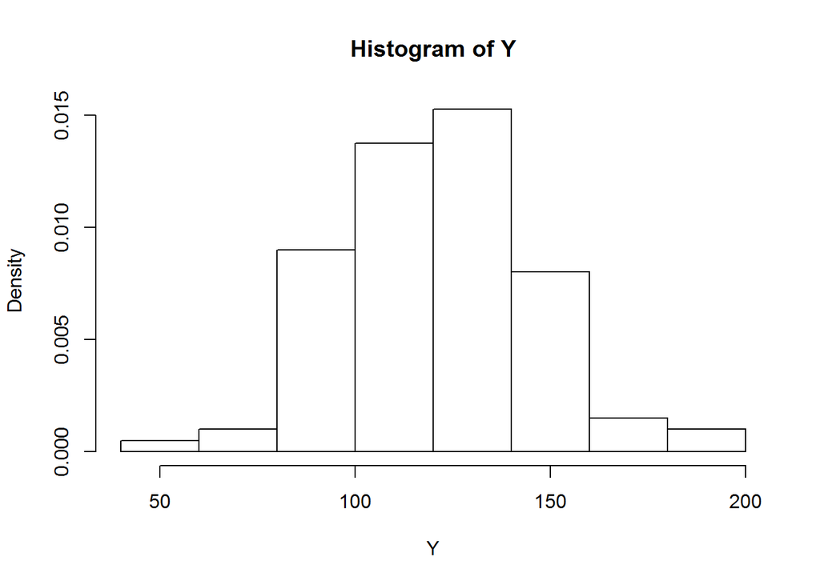

```r
meanMLE<-mean(Y)
hist(Y,freq=F)
```

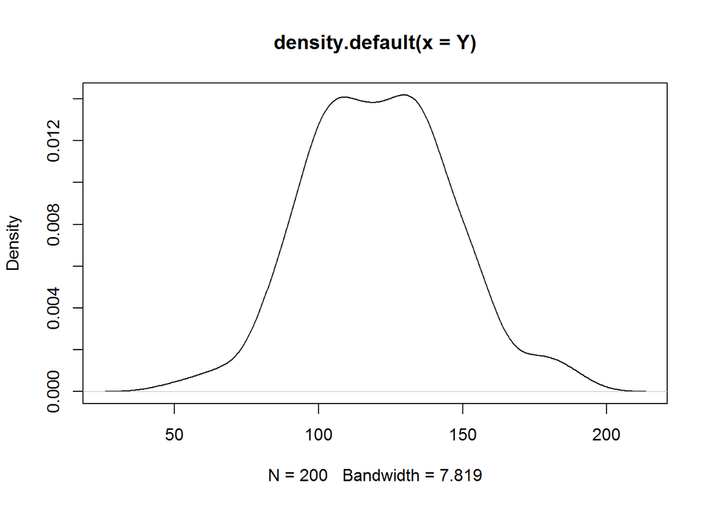

```r
plot(density(Y))
```

To test $H_0$ use z-statistic (known $\sigma$).  
Then calculate p-value for two-sided alternative.

```r
(zStat<-(meanMLE-Theoretical.data["Mean"])/(Theoretical.data["Sd"]/sqrt(nSample)))
```

```
##      Mean
## 0.6185837
```

```r
(sSidedP<-pnorm(zStat,lower.tail = F)+pnorm(-zStat,lower.tail = T))
```

```
##      Mean
## 0.5361906
```

Finally, distribution of the data estimated by FNP:

```r
(MLE.data<-c(Mean=meanMLE,Sd=Theoretical.data["Sd"]))
```

```
##     Mean    Sd.Sd
## 121.0935  25.0000
```

## 3.3 Bayesian approach by formula, week prior

Set the model as
$$y_i \sim N(\theta,\sigma),$$
where $\theta$ is unknown and $\sigma=25$.
Set prior distribution for the mean value as low informative Gaussian with parameters $M=100,~\sigma_{\mu}=200$, i.e.
$$\theta \sim N(M,\sigma_{\mu}).$$

```r
priorParamWeak<-c(Mean=100,Sd=200)
```

Obtain posterior distribution using formulas for conjugate Gaussian distribution:
$$\mu_{post}= \frac{\mu_{prior} \gamma_{prior}+ \bar{y} \gamma_{data}}{ \gamma_{prior}+ \gamma_{data}}=\frac{M \gamma_{prior}+ \bar{y} \gamma_{data}}{ \gamma_{prior}+ \gamma_{data}}=M \frac{\gamma_{prior}}{\gamma_{prior}+ \gamma_{data}}+\bar{y}\frac{\gamma_{data}}{\gamma_{prior}+ \gamma_{data}},$$
$$\sigma^2_{post}=\frac{1}{\gamma_{prior}+ \gamma_{data}},$$
where $n$ is the sample size and $\gamma_{data}$ and $\gamma_{prior}$ are data precision and prior precision, correspondingly:
$$\gamma_{data}=\frac{n}{\sigma^2};~\gamma_{prior}=\frac{1}{\sigma_{\mu}^2}$$

(Skipped Code)

```r
posterParamWeak<-c(Mean=pMean,Sd=pSd)
```

Bayesian estimate is obtained as $\mu_{post}=$ 100 $\times$ 7.811889710^{-5} $+$ 121.0935118 $\times$ 0.9999219, showing no compromize between likelihood and prior.

Plot theoretical (simulated), estimated by MLE and estimated by Bayesian analysis densities.

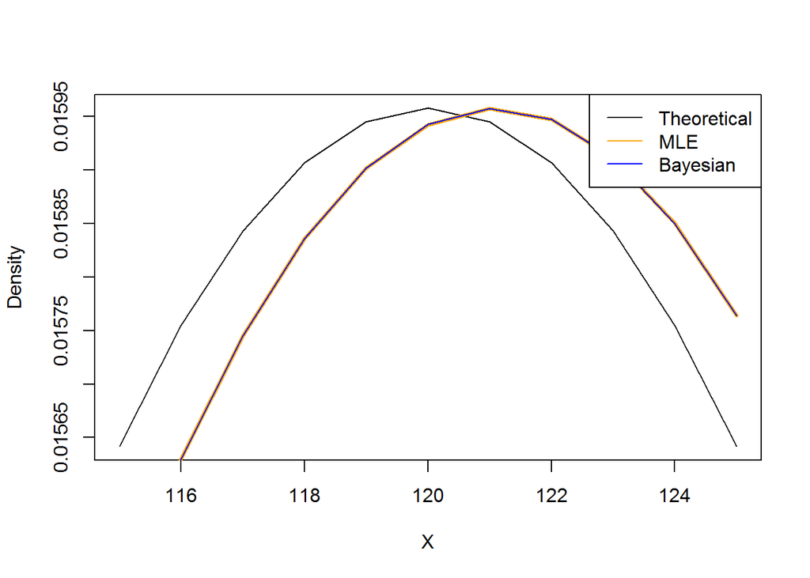

```r
Bayes.dataWeak<-c(posterParamWeak["Mean"],Theoretical.data["Sd"])
X<-seq(from=115,to=125,by=1)
plot(X,dnorm(X,Theoretical.data[1],Theoretical.data[2]),
     type="l",xlab="X",ylab="Density")
lines(X,dnorm(X,meanMLE,si),col="orange",lwd=3)
lines(X,dnorm(X,posterParamWeak[1],si),col="blue")
legend("topright",
        legend=c("Theoretical","MLE","Bayesian"),
        col=c("black","orange","blue"),
       lty=1)
```

For the sample length 200 and low informative prior Bayesian estimate is very close to MLE in comparison with the prior.  
In addition standard deviation of the posterior distribution collapsed from 200 to 1.7676979

```r
rbind(Theoretical.data,MLE.data,Bayes.dataWeak)
```

```
##                      Mean Sd
## Theoretical.data 120.0000 25
## MLE.data         121.0935 25
## Bayes.dataWeak   121.0919 25
```

```r
rbind(priorParamWeak,posterParamWeak)
```

```
##                     Mean         Sd
## priorParamWeak  100.0000 200.000000
## posterParamWeak 121.0919   1.767698
```

## 3.4 Bayesian approach by formula, strong prior

Repeat Bayesian analysis with stronger prior $M=100,~\sigma_{\mu}=2$.

```r
rbind(priorParamStrong,posterParamStrong)
```

```
##                      Mean       Sd
## priorParamStrong  100.000 2.000000
## posterParamStrong 111.842 1.324532
```

Bayesian estimate of the mean shifted towards mode of the prior distribution: now the mean of posterior distribution is obtained by $\mu_{post}=$ 100 $\times$ 0.4385965 $+$ 121.0935118 $\times$ 0.5614035.

Shift of the lower level parameter towards mode of the higher level parameter is **shrinkage**.

## 3.5 Using JAGS to estimate mean of normal distribution with known variance

### 3.5.1 Data

```r
suppressWarnings(source(paste(dataPath,"DBDA2E-utilities.R",sep="/")))
```

Prepare the data list `dataList` in the format required by JAGS:

```r
list(y, # data vector
     nSample # length of the sample)
```

(Skipped Code)

```r
names(dataList)
```

```
## [1] "y"       "nSample"
```

### 3.5.2 Preparation of the model for JAGS

Line 1 of the model describes generation of the data according to the likelihood function: $y_i \sim dnorm(\theta,\sigma)$.  
Line 2 of the model describes generation of the parameter $\theta$ from the prior distribution: $\theta \sim dnorm(M,\sigma_{\mu})$.  
In this case parameters of the prior distribution should be defined. For example, like above set $M = 100, \sigma_{\mu}=200$.

The format of the model description for JAGS is a string of the form:

```r
model1NormalSample= "
  model {
    # Description of data
    # Description of prior
  }
"
```

Data are described as `for` loop.  
Prior is described as typical formula:  
“lower order parameter $\sim$ density(higher order parameters)”.

**Note**. In JAGS normal distribution is specified with mean value and precision, i.e. instead of $dnorm(\mu,\sigma)$ use $dnorm(\mu,\frac{1}{\sigma^2})$.

(Skipped Code)

Note that variables names for the data and data length `y`, `nSample` in the description have to match the names of the data list.

The next step of preparation of the model description for JAGS is saving it to a temporary text file `Tempmodel.txt`.

```r
writeLines(model1NormalSample,con="Tempmodel.txt")
```

### 3.5.3 Initializing Markov chains

To initialize trajectories define a list of lists with several values or create a function that returns an init value every time it is called.  
JAGS will call this function when it starts a new chain.

General syntax of initiation function is:

```r
initsList<-function() {
  # Definition of thetaInit
  return(list(theta=thetaInit))
}
```

For example, select starting point from normal distribution centered at MLE with some reasonable standard deviation.

(Skipped Code)

Check how initiation works by running the function several times.

```r
initsList()
```

```
## $theta
## [1] 109.9084
```

### 3.5.4 Sending information to JAGS

Next step is getting all information to JAGS using `jags.model()` from library `rjags`.  
This function transfers the data, the model specification and the initial values to JAGS and requests JAGS to select appropriate sampling method.

```r
suppressWarnings(library(rjags))
jagsModel<-jags.model(file="TempModel.txt",data=dataList,n.chains=3,n.adapt=500)
```

In `jags.model` parameter `n.chains` specifies the number of chains to run (defaults to 1) and parameter `n.adapt` sets the number of steps JAGS can take to tune the sampling method (defaults to 1000).

The object returned by `jags.model` contains all information that we need to communicate to JAGS about the problem in the format suitable for JAGS.

### 3.5.5 Running MCMC in JAGS: burn in and main run

Now run JAGS chains for 600 steps to complete burn in, i.e. transition to a stable distribution of Markov chain.

```r
update(jagsModel,n.iter=600)
```

After completing burn in generate MCMC trajectories representing the posterior distribution for the model.

```r
codaSamples<-coda.samples(jagsModel,variable.names=c("theta"),n.iter=3334)
list.samplers(jagsModel)
```

```
## $`bugs::ConjugateNormal`
## [1] "theta"
```

```r
head(codaSamples)
```

```
## [[1]]
## Markov Chain Monte Carlo (MCMC) output:
## Start = 601
## End = 607
## Thinning interval = 1
##         theta
## [1,] 123.6202
## [2,] 120.1674
## [3,] 121.2257
## [4,] 120.5346
## [5,] 121.5115
## [6,] 121.5211
## [7,] 120.4466
##
## [[2]]
## Markov Chain Monte Carlo (MCMC) output:
## Start = 601
## End = 607
## Thinning interval = 1
##         theta
## [1,] 119.9291
## [2,] 120.5447
## [3,] 120.4374
## [4,] 123.8270
## [5,] 118.8253
## [6,] 122.1771
## [7,] 121.8521
##
## [[3]]
## Markov Chain Monte Carlo (MCMC) output:
## Start = 601
## End = 607
## Thinning interval = 1
##         theta
## [1,] 121.6286
## [2,] 121.4244
## [3,] 122.1145
## [4,] 121.9087
## [5,] 122.8487
## [6,] 119.2399
## [7,] 118.6504
##
## attr(,"class")
## [1] "mcmc.list"
```

Besides the model specification object `coda.samples()` takes a vector of character strings corresponding to the names of parameters to record `variable.names` and the number of iterations to run `n.iter`.  
In this example there are 3 chains, to the total number of iterations will be about 10,000.  
Use function `list.samplers` to show the samplers applied to the model.

### 3.5.6 Analyzing convergence

Analyze convergence of chains using following tools:

1. Summary

```r
summary(codaSamples)
```

```
##
## Iterations = 601:3934
## Thinning interval = 1
## Number of chains = 3
## Sample size per chain = 3334
##
## 1. Empirical mean and standard deviation for each variable,
##    plus standard error of the mean:
##
##           Mean             SD       Naive SE Time-series SE
##      121.07654        1.77632        0.01776        0.01772
##
## 2. Quantiles for each variable:
##
##  2.5%   25%   50%   75% 97.5%
## 117.6 119.9 121.1 122.3 124.6
```

2. Traceplot

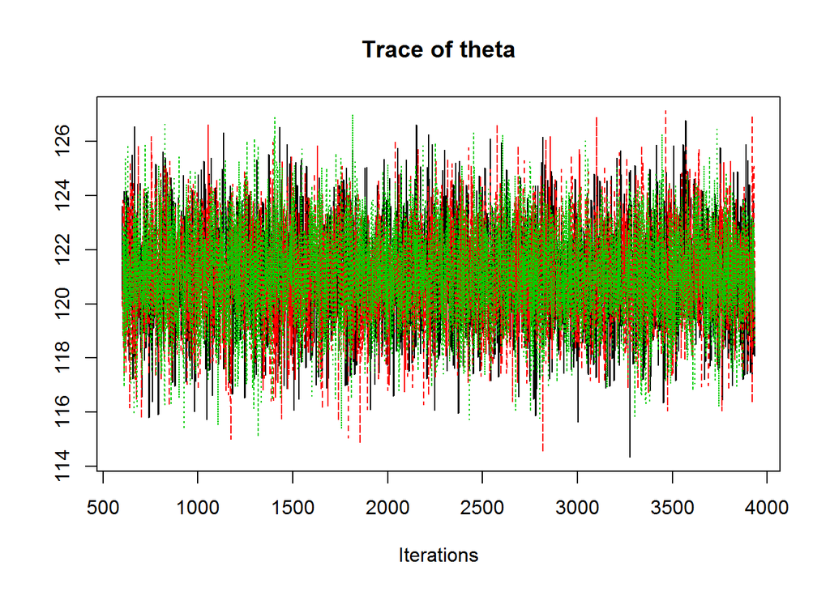

```r
coda::traceplot(codaSamples)
```

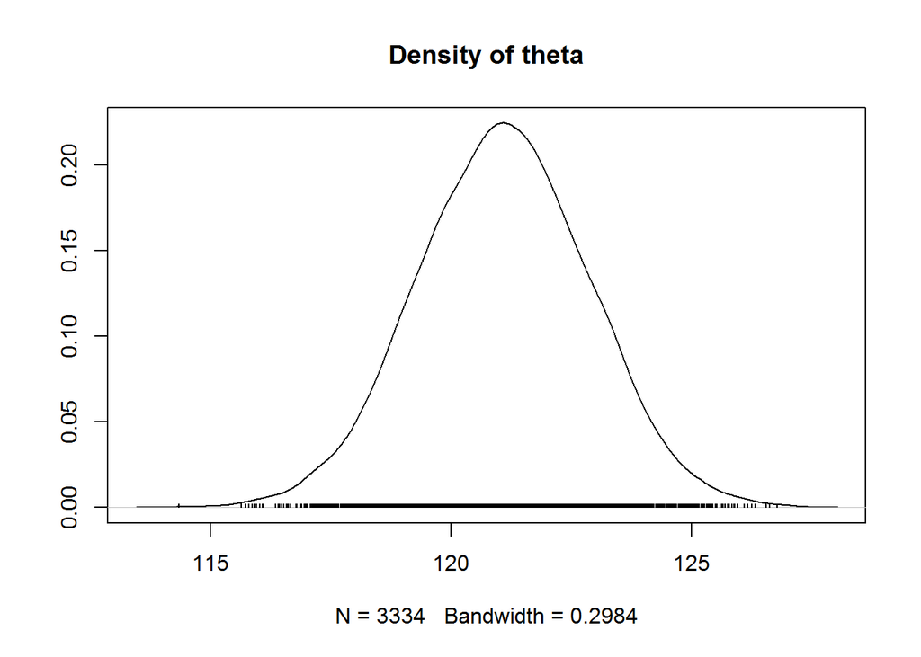

```r
densplot(codaSamples)
```

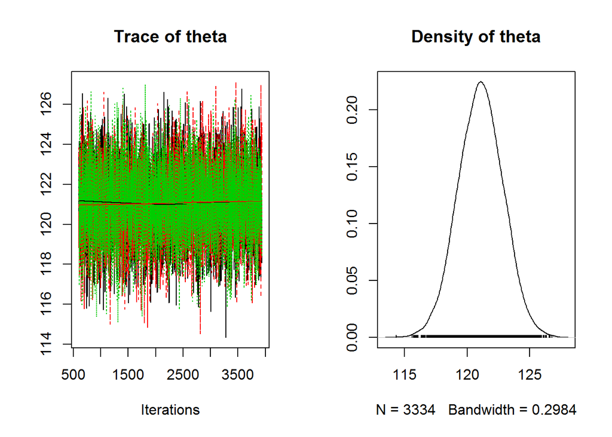

```r
plot(codaSamples)
```

3. Autocorrelation and effective size

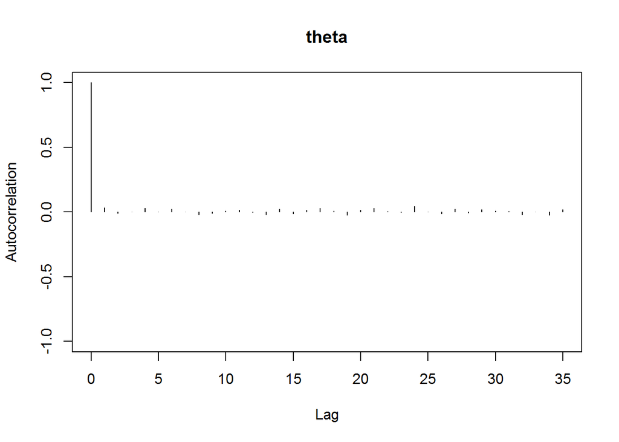

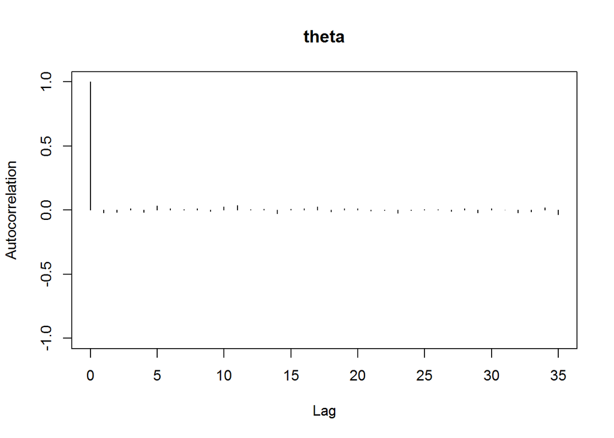

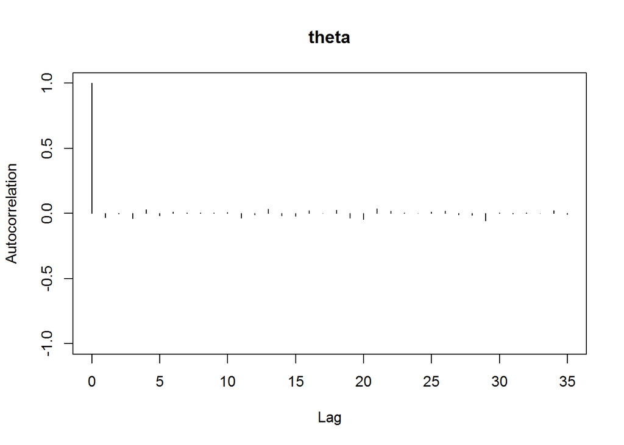

```r
autocorr.plot(codaSamples,ask=F)
```

```r
effectiveSize(codaSamples)
```

```
##    theta
## 10096.27
```

The $ESS$ number is consistent with the autocorrelation function.

4. Shrink factor

```r
gelman.diag(codaSamples)
```

```
## Potential scale reduction factors:
##
##       Point est. Upper C.I.
## theta          1          1
```

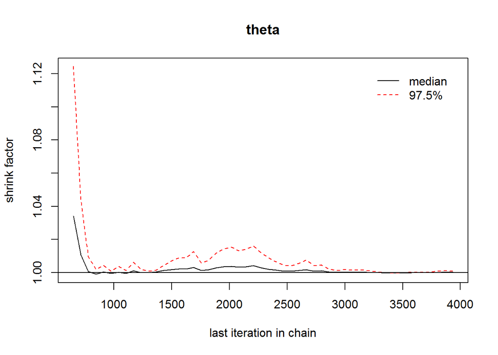

```r
gelman.plot(codaSamples)
```

### 3.5.7 Analyzing and interpreting the results

1. Find the mean values and standard deviations of posterior distributions corresponding to different chains and compare them with MLE:

(Skipped Code)

```r
rbind(Means=chainMeans,SD=chainSd)
```

```
##       [,1]     [,2]     [,3]
## Means 121.0656 121.0552 121.1089
## SD    1.783401 1.772021 1.773607
```

Compare the posterior densities generated by 3 chains with analytical posterior distribution:

```r
(l<-min(unlist(codaSamples))-.05)
```

```
## [1] 114.2906
```

```r
(h<-max(unlist(codaSamples))+.05)
```

```
## [1] 127.1788
```

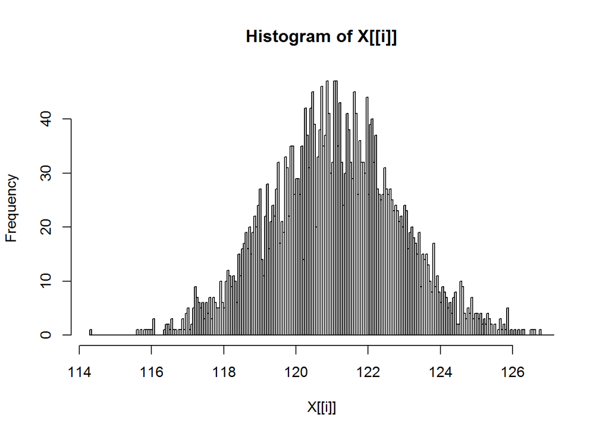

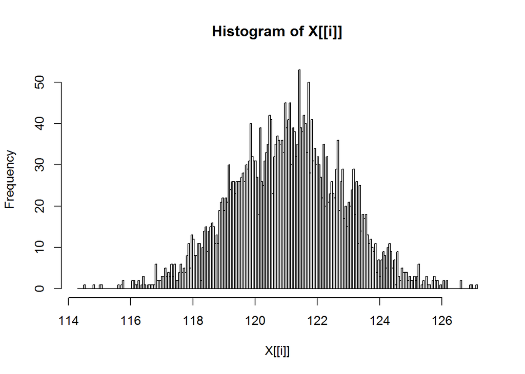

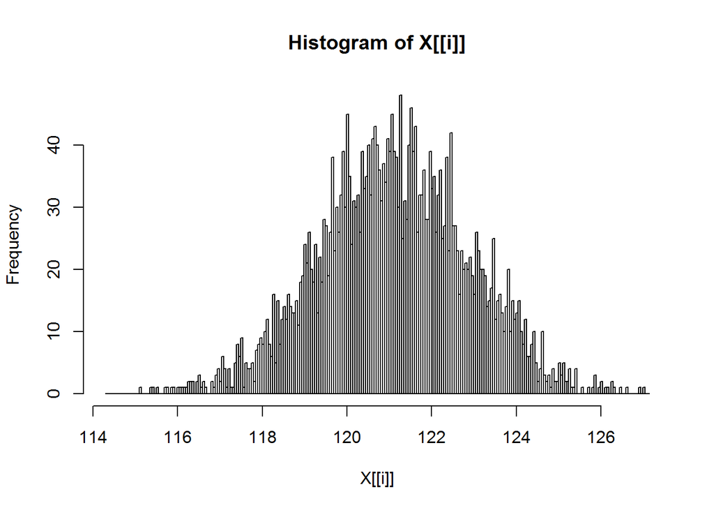

```r
histBreaks<-seq(l,h,by=.05)
postHist<-lapply(codaSamples,hist,breaks=histBreaks)
```

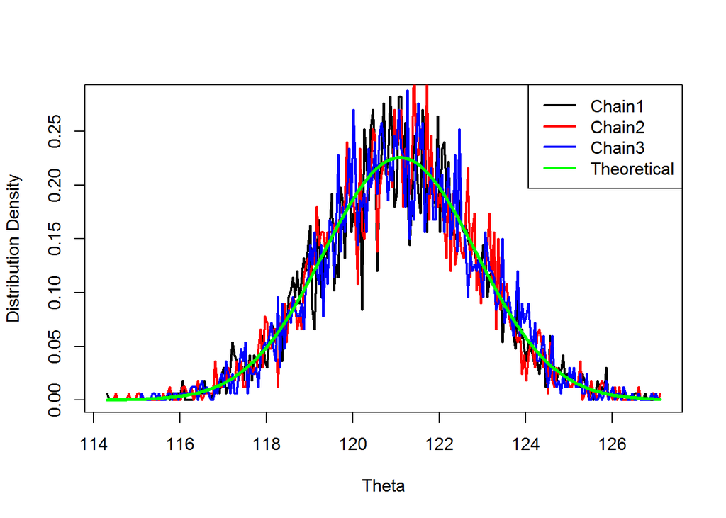

```r
plot(postHist[[1]]$mids,postHist[[1]]$density,type="l",
     col="black",lwd=2,ylab="Distribution Density",xlab="Theta")
lines(postHist[[2]]$mids,postHist[[2]]$density,type="l",col="red",lwd=2)
lines(postHist[[3]]$mids,postHist[[3]]$density,type="l",col="blue",lwd=2)
lines(postHist[[3]]$mids,
      dnorm(postHist[[3]]$mids,posterParamWeak["Mean"],posterParamWeak["Sd"]),
      type="l",col="green",lwd=3)
legend("topright",legend=c("Chain1","Chain2","Chain3","Theoretical"),col=c("black","red","blue","green"),lwd=2)
```

# 4 Hierarchical model: two groups of Gaussian observations

Consider now two groups of Gaussian observations with unknown means $\mu_1,~\mu_2$ and same known standard deviation $\sigma=25$.

## 4.1 Data

Create data, prepare them for JAGS.  
Keep the first group sample as in the previous section: theoretical mean 120 and theoretical known standard deviation 25.  
Simulate second sample with the same standard deviation and theoretical mean 150.  
Combine both samples together and add second column containing group number.

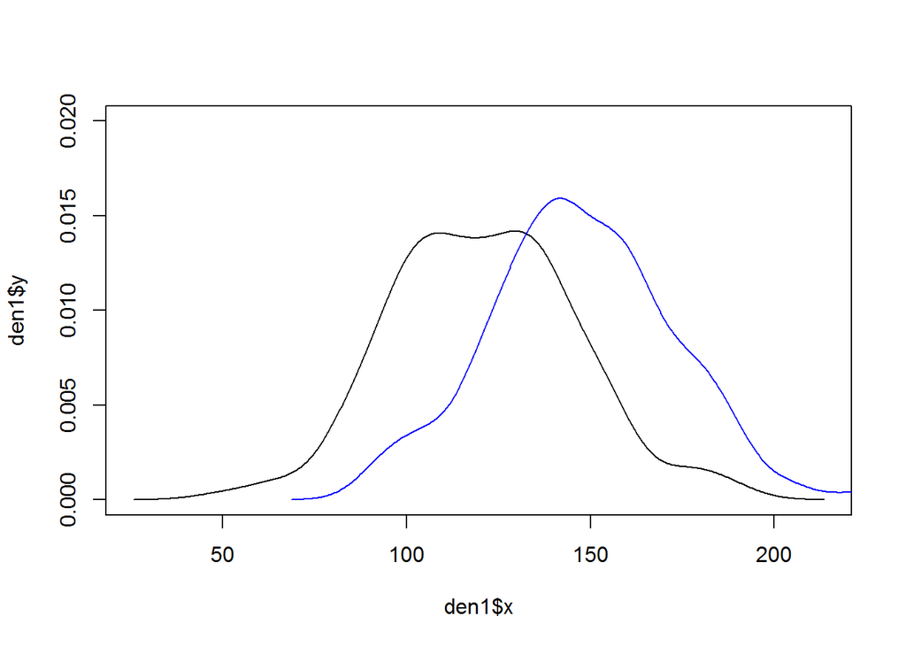

```r
set.seed(7952)
Y2<-rnorm(nSample,mean=150,sd=25)
Y2<-rbind(cbind(Y,rep(1,nSample)),cbind(Y2,rep(2,nSample)))
colnames(Y2)<-c("y","s")
den1<-density(subset(Y2,Y2[,2]==1)[,1])
den2<-density(subset(Y2,Y2[,2]==2)[,1])
plot(den1$x,den1$y,type="l",ylim=c(0,.02))
lines(den2$x,den2$y,col="blue")
```

The sample from 2 groups now is `Y2`.

Create data for JAGS.

```r
y=Y2[,"y"]
s<-Y2[,"s"]
nSample<-length(y)
nGr<-length(unique(s))
dataList<-list(y=y,s=s,nSample=nSample,nGr=nGr)
names(dataList)
```

```
## [1] "y"       "s"       "nSample" "nGr"
```

## 4.2 Different mean values, common weak prior

In this section consider model structure with common weak prior for mean values of both groups.  
**Think about situations in which common prior is a reasonable assumption**.

Select hyper-parameters of the common prior normal distribution as in the previous section: $M=100,~\sigma_{\mu}=200$.

### 4.2.1 Model description

Prepare the model string.  
The difference from one-group data description is that now prior distribution for $\theta$ is described in a loop over all groups.

(Skipped Code)

### 4.2.2 Initialization and sending the model to JAGS

Initialize chains randomly around MLE.

(Skipped Code)

Check initiation:

```r
initsList()
```

```
## $theta
## [1] 140.0251 142.9089
```

Send the model to JAGS.

Set main parameters:

- Define vector of parameters for monitoring and recording
- Define number of steps for adaptation of samplers
- Define number of burn-in steps
- Define number of chains $n_{chains}$
- Define number of saved steps of Markov chains $n_{steps}$
- Define number of iterations per chain as $n_{iter}=\frac{n_{steps}}{n_{chains}}$

Use `jags.model()` to transfer information to JAGS.  
Arguments for this function are: model string, data list, initiation function name, number of chains and number of steps for adaptation.

(Skipped Code)

### 4.2.3 Running the model

Run burn in by using `update()`.

```r
update( jagsModel , n.iter=burnInSteps )
```

Make the main run by using `coda.samples()`.

```r
codaSamples2Groups1Prior = coda.samples( jagsModel ,
                                         variable.names=parameters,
                                         n.iter=nIter)
head(codaSamples2Groups1Prior)
```

```
## [[1]]
## Markov Chain Monte Carlo (MCMC) output:
## Start = 501
## End = 507
## Thinning interval = 1
##      theta[1] theta[2]
## [1,] 121.1303 146.6102
## [2,] 118.9512 147.6236
## [3,] 122.3367 150.1863
## [4,] 119.0154 147.2925
## [5,] 122.7660 147.4372
## [6,] 121.2117 145.7788
## [7,] 122.2685 150.2573
##
## [[2]]
## Markov Chain Monte Carlo (MCMC) output:
## Start = 501
## End = 507
## Thinning interval = 1
##      theta[1] theta[2]
## [1,] 116.5707 146.0138
## [2,] 122.1029 147.3433
## [3,] 121.7641 149.4401
## [4,] 120.2918 146.1626
## [5,] 119.1506 145.0220
## [6,] 121.9633 146.0411
## [7,] 125.0674 150.0325
##
## [[3]]
## Markov Chain Monte Carlo (MCMC) output:
## Start = 501
## End = 507
## Thinning interval = 1
##      theta[1] theta[2]
## [1,] 122.5984 148.8960
## [2,] 123.0161 145.4138
## [3,] 122.3347 150.6049
## [4,] 124.0967 148.9856
## [5,] 119.9414 145.8712
## [6,] 122.5553 146.1852
## [7,] 121.0496 145.7443
##
## attr(,"class")
## [1] "mcmc.list"
```

```r
list.samplers(jagsModel)
```

```
## $`bugs::ConjugateNormal`
## [1] "theta[2]"
##
## $`bugs::ConjugateNormal`
## [1] "theta[1]"
```

### 4.2.4 Analysis

Analyze convergence.

```r
summary(codaSamples2Groups1Prior)
```

```
##
## Iterations = 501:17167
## Thinning interval = 1
## Number of chains = 3
## Sample size per chain = 16667
##
## 1. Empirical mean and standard deviation for each variable,
##    plus standard error of the mean:
##
##           Mean    SD Naive SE Time-series SE
## theta[1] 121.1 1.767 0.007902       0.007901
## theta[2] 147.4 1.763 0.007883       0.007842
##
## 2. Quantiles for each variable:
##
##           2.5%   25%   50%   75% 97.5%
## theta[1] 117.6 119.9 121.1 122.3 124.5
## theta[2] 143.9 146.2 147.3 148.5 150.8
```

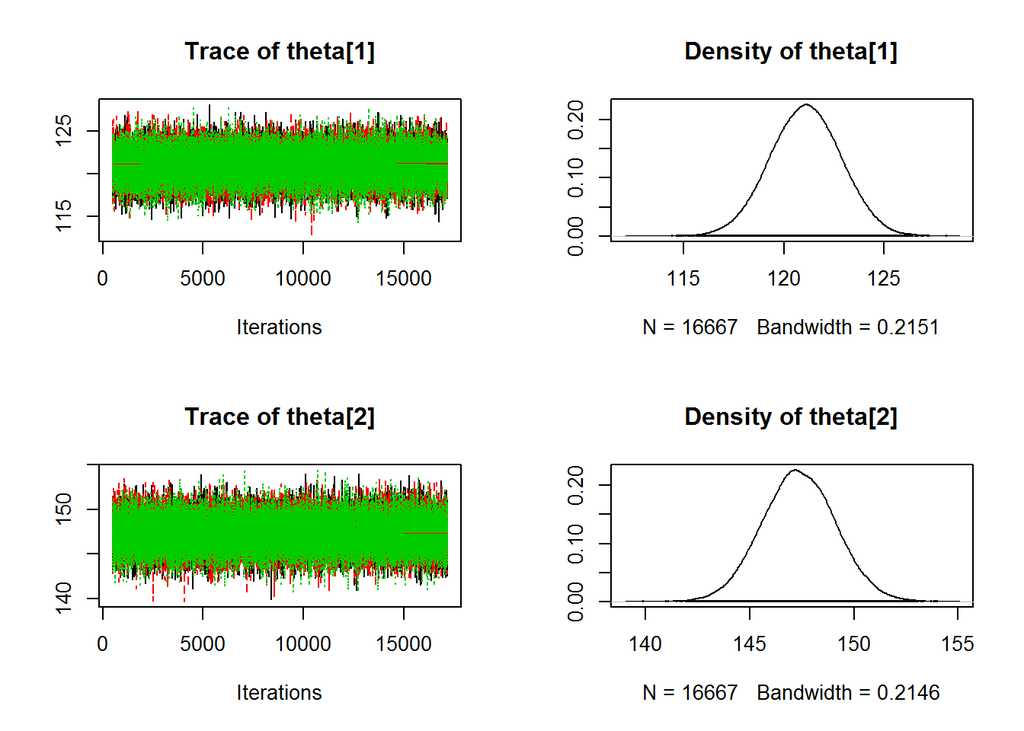

```r
plot(codaSamples2Groups1Prior)
```

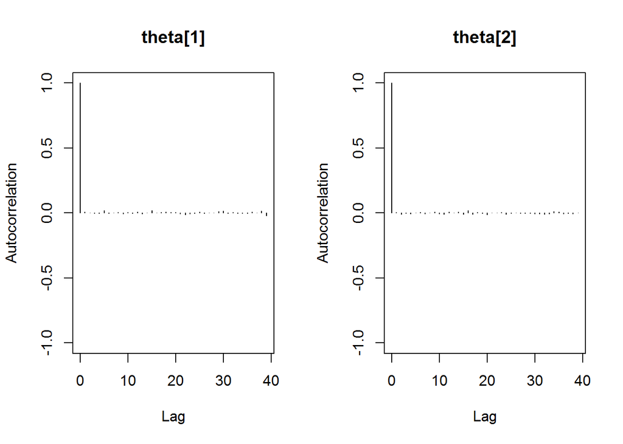

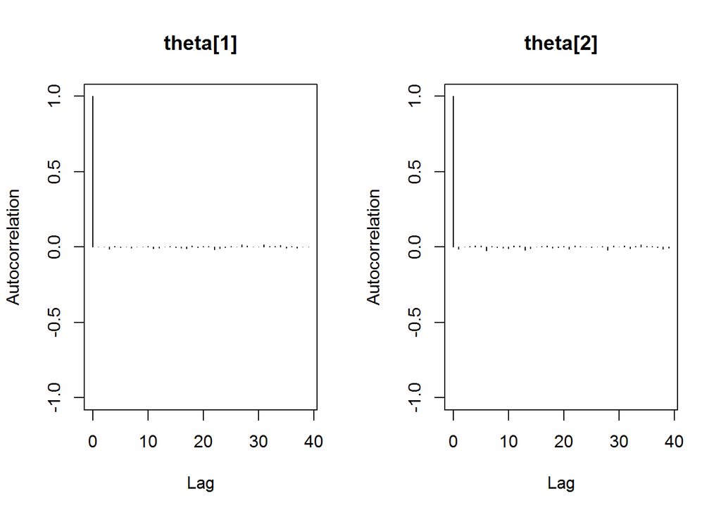

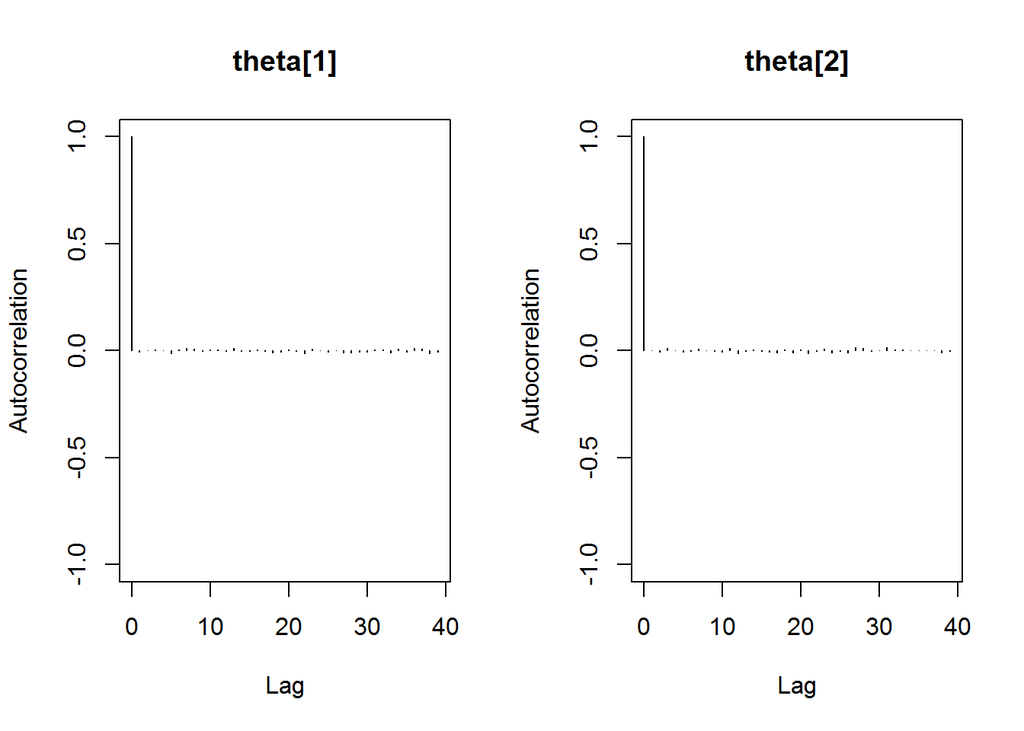

```r
autocorr.plot(codaSamples2Groups1Prior,ask=F)
```

```r
effectiveSize(codaSamples2Groups1Prior)
```

```
## theta[1] theta[2]
## 50001.00 50522.33
```

```r
gelman.diag(codaSamples2Groups1Prior)
```

```
## Potential scale reduction factors:
##
##          Point est. Upper C.I.
## theta[1]          1          1
## theta[2]          1          1
##
## Multivariate psrf
##
## 1
```

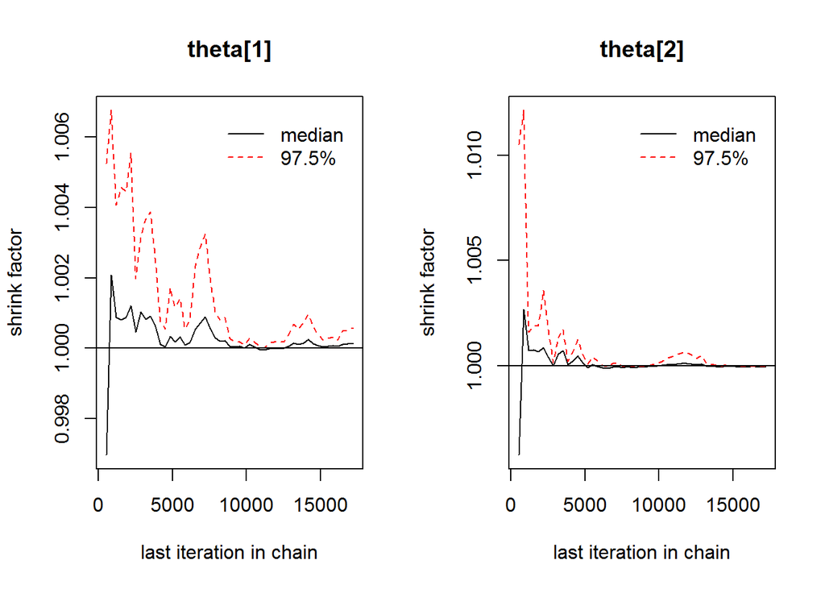

```r
gelman.plot(codaSamples2Groups1Prior)
```

Check estimated means.

```r
matrix(unlist(lapply(codaSamples2Groups1Prior,function(z) apply(z,2,mean))),ncol=3)
```

```
##          [,1]     [,2]     [,3]
## [1,] 121.0802 121.1061 121.0605
## [2,] 147.3593 147.3585 147.3473
```

Plot posterior densities.

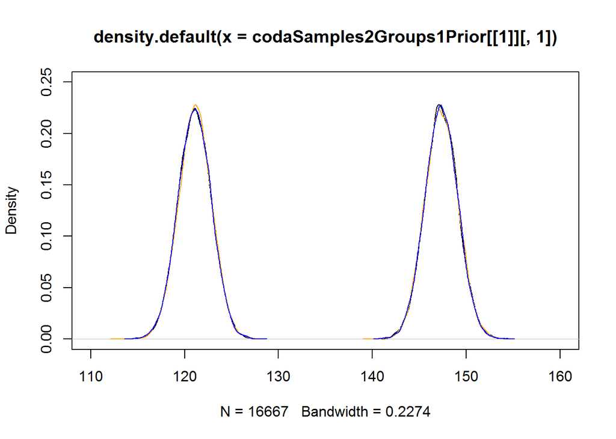

```r
plot(density(codaSamples2Groups1Prior[[1]][,1]),xlim=c(110,160),ylim=c(0,.25))
lines(density(codaSamples2Groups1Prior[[1]][,2]))
lines(density(codaSamples2Groups1Prior[[2]][,1]),col="orange")
lines(density(codaSamples2Groups1Prior[[2]][,2]),col="orange")
lines(density(codaSamples2Groups1Prior[[3]][,1]),col="blue")
lines(density(codaSamples2Groups1Prior[[3]][,2]),col="blue")
```

Calculate HDIs for each chain.

```r
suppressWarnings(library(HDInterval))
```

```r
lapply(codaSamples2Groups1Prior,function(z) hdi(as.matrix(z)))
```

```
## [[1]]
##       theta[1] theta[2]
## lower 117.6151 143.9771
## upper 124.4869 150.8694
## attr(,"credMass")
## [1] 0.95
##
## [[2]]
##       theta[1] theta[2]
## lower 117.5932 143.9804
## upper 124.5143 150.8434
## attr(,"credMass")
## [1] 0.95
##
## [[3]]
##       theta[1] theta[2]
## lower 117.6134 143.7888
## upper 124.4948 150.6898
## attr(,"credMass")
## [1] 0.95
```

Find differences between $\theta_1$ and $\theta_2$.

```r
chainDiffs<-lapply(codaSamples2Groups1Prior,function(z) z[,2]-z[,1])
lapply(chainDiffs,function(z) hdi(as.matrix(z)))
```

```
## [[1]]
##           var1
## lower 21.30779
## upper 31.02470
## attr(,"credMass")
## [1] 0.95
##
## [[2]]
##           var1
## lower 21.49642
## upper 31.20208
## attr(,"credMass")
## [1] 0.95
##
## [[3]]
##           var1
## lower 21.42563
## upper 31.11082
## attr(,"credMass")
## [1] 0.95
```

Find left 95% HDI boundaries for the chain differences and plot them.

```r
  (leftBounds<-unlist(lapply(chainDiffs,function(z) hdi(as.matrix(z))[1])))
```

```
## [1] 21.30779 21.49642 21.42563
```

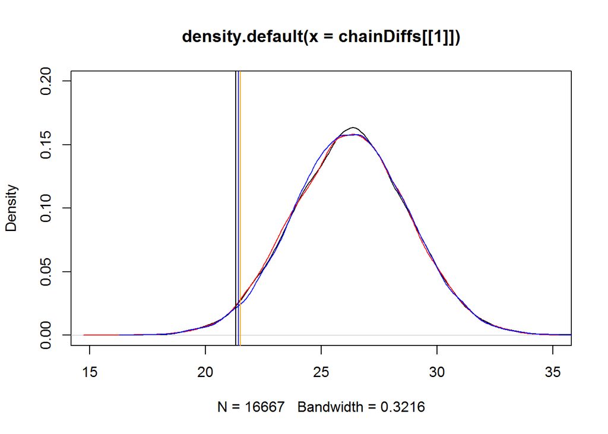

```r
  plot(density(chainDiffs[[1]]),xlim=c(15,35),ylim=c(0,.2),col="black")
  lines(density(chainDiffs[[2]]),col="red")
  lines(density(chainDiffs[[3]]),col="blue")
  abline(v=leftBounds,col=c("black","orange","blue"))
```

For the given sample and prior distribution mean values of the 2 groups are clearly different based on 95% HDI for all 3 chains.

## 4.3 Experimenting with prior hyperparameters

Repeat calculations with different prior hyperparameters.

To do that organize all steps of running MCMC with JAGS in a function `runMCMC2Groups<-function(prMean,prSD,dat)`, where `prMean` and `prSD` are the the prior hyperparameters and `dat` is the data list.

Note that in order to pass arguments of the function to JAGS model description you need to append them to the data list:

- First put them in a list `hyper<-list(hypeMean=prMean,hypeSD=prSD)`
- Then combine list `hyper` with the data when run `jags.model()`:  
  `jags.model("TEMPmodel.txt",data=append(dat,hyper),...)`
- After that parameters can be used in the description of the model as `dnorm(hypeMean,1/hypeSD^2)`.

The function should return the simulated chains.

(Skipped Code)

```r
runMCMC2Groups<-function(prMean,prSD,dat){
  model2NormalSamples =
"
model {
    for ( i in 1:nSample ) {
      y[i] ~ dnorm( theta[s[i]],1/25^2 )
    }
    for ( sIdx in 1:nGr ) {      # Different thetas from same prior
      theta[sIdx] ~ dnorm(hypeMean,1/hypeSD^2)
    }
}
" # close quote for modelString
writeLines( model2NormalSamples , con="TEMPmodel.txt" )
parameters = c("theta")      # The parameters to be monitored
adaptSteps = 500             # Number of steps to adapt the samplers
burnInSteps = 500            # Number of steps to burn-in the chains
nChains = 3                  # nChains should be 2 or more for diagnostics
numSavedSteps<-50000
nIter = ceiling(numSavedSteps / nChains )
hyper<-list(hypeMean=prMean,hypeSD=prSD)
# Create, initialize, and adapt the model:
jagsModel = jags.model( "TEMPmodel.txt" , data=append(dat,hyper) , inits=initsList ,
                          n.chains=nChains , n.adapt=adaptSteps )
update( jagsModel , n.iter=burnInSteps )
codaSamplesResult<- coda.samples( jagsModel,variable.names=parameters,n.iter=nIter)
codaSamplesResult
}
```

Call function with the following combinations of parameters:

### 4.3.1 Run: `hypeMean=130; hypeSD=200`

```r
Run.130.200<-runMCMC2Groups(130,200,dataList)
lapply(Run.130.200,function(z) apply(z,2,mean))
```

```
## [[1]]
## theta[1] theta[2]
## 121.0972 147.3746
##
## [[2]]
## theta[1] theta[2]
## 121.0959 147.3466
##
## [[3]]
## theta[1] theta[2]
## 121.0727 147.3670
```

```r
chainDiffs<-lapply(Run.130.200,function(z) z[,2]-z[,1])
lapply(chainDiffs,function(z) hdi(as.matrix(z)))
```

```
## [[1]]
##           var1
## lower 21.32461
## upper 31.09967
## attr(,"credMass")
## [1] 0.95
##
## [[2]]
##           var1
## lower 21.40547
## upper 31.07929
## attr(,"credMass")
## [1] 0.95
##
## [[3]]
##           var1
## lower 21.30730
## upper 30.94617
## attr(,"credMass")
## [1] 0.95
```

### 4.3.2 Run: `hypeMean=130; hypeSD=0.2`

```r
Run.130.2<-runMCMC2Groups(130,.2,dataList)
lapply(Run.130.2,function(z) apply(z,2,mean))
```

```
## [[1]]
## theta[1] theta[2]
## 129.8876 130.2203
##
## [[2]]
## theta[1] theta[2]
## 129.8886 130.2193
##
## [[3]]
## theta[1] theta[2]
## 129.8893 130.2197
```

```r
chainDiffs<-lapply(Run.130.2,function(z) z[,2]-z[,1])
lapply(chainDiffs,function(z) hdi(as.matrix(z)))
```

```
## [[1]]
##             var1
## lower -0.2406586
## upper  0.8670839
## attr(,"credMass")
## [1] 0.95
##
## [[2]]
##             var1
## lower -0.2123761
## upper  0.8916671
## attr(,"credMass")
## [1] 0.95
##
## [[3]]
##             var1
## lower -0.2138950
## upper  0.8752615
## attr(,"credMass")
## [1] 0.95
```

### 4.3.3 Run: `hypeMean=100; hypeSD=0.2`

```r
Run.100.2<-runMCMC2Groups(100,.2,dataList)
lapply(Run.100.2,function(z) apply(z,2,mean))
```

```
## [[1]]
## theta[1] theta[2]
## 100.2663 100.5951
##
## [[2]]
## theta[1] theta[2]
## 100.2656 100.5994
##
## [[3]]
## theta[1] theta[2]
## 100.2652 100.6006
```

```r
chainDiffs<-lapply(Run.100.2,function(z) z[,2]-z[,1])
lapply(chainDiffs,function(z) hdi(as.matrix(z)))
```

```
## [[1]]
##             var1
## lower -0.2093411
## upper  0.8875026
## attr(,"credMass")
## [1] 0.95
##
## [[2]]
##             var1
## lower -0.2154396
## upper  0.8829504
## attr(,"credMass")
## [1] 0.95
##
## [[3]]
##             var1
## lower -0.2267519
## upper  0.8734484
## attr(,"credMass")
## [1] 0.95
```

```r
Run.170.2<-runMCMC2Groups(170,.2,dataList)
lapply(Run.170.2,function(z) apply(z,2,mean))
```

```
## [[1]]
## theta[1] theta[2]
## 169.3800 169.7133
##
## [[2]]
## theta[1] theta[2]
## 169.3839 169.7140
##
## [[3]]
## theta[1] theta[2]
## 169.3792 169.7124
```

```r
chainDiffs<-lapply(Run.170.2,function(z) z[,2]-z[,1])
lapply(chainDiffs,function(z) hdi(as.matrix(z)))
```

```
## [[1]]
##             var1
## lower -0.2238266
## upper  0.8790891
## attr(,"credMass")
## [1] 0.95
##
## [[2]]
##             var1
## lower -0.2173123
## upper  0.8949518
## attr(,"credMass")
## [1] 0.95
##
## [[3]]
##             var1
## lower -0.2270330
## upper  0.8692323
## attr(,"credMass")
## [1] 0.95
```

**Explain the results of running hierarchical model with different sets of hyperparameters**.

## 4.4 FNP approach: ANOVA

Compare results with fixed effects ANOVA model.

```r
head(Y2)
```

```
##             y s
## [1,] 101.8935 1
## [2,] 156.0978 1
## [3,] 131.2486 1
## [4,] 117.3651 1
## [5,] 148.6038 1
## [6,] 151.5923 1
```

```r
mANOVA<-lm(y~as.factor(s),as.data.frame(Y2))
summary(mANOVA)
```

```
##
## Call:
## lm(formula = y ~ as.factor(s), data = as.data.frame(Y2))
##
## Residuals:
##     Min      1Q  Median      3Q     Max
## -71.943 -17.577  -1.154  15.522  84.740
##
## Coefficients:
##               Estimate Std. Error t value Pr(>|t|)
## (Intercept)    121.094      1.778   68.11   <2e-16 ***
## as.factor(s)2   26.273      2.514   10.45   <2e-16 ***
## ---
## Signif. codes:  0 '***' 0.001 '**' 0.01 '*' 0.05 '.' 0.1 ' ' 1
##
## Residual standard error: 25.14 on 398 degrees of freedom
## Multiple R-squared:  0.2153, Adjusted R-squared:  0.2133
## F-statistic: 109.2 on 1 and 398 DF,  p-value: < 2.2e-16
```

```r
anova(mANOVA)
```

```
## Analysis of Variance Table
##
## Response: y
##               Df Sum Sq Mean Sq F value    Pr(>F)
## as.factor(s)   1  69029   69029  109.18 < 2.2e-16 ***
## Residuals    398 251627     632
## ---
## Signif. codes:  0 '***' 0.001 '**' 0.01 '*' 0.05 '.' 0.1 ' ' 1
```